# Boruta_group 5 (1)

## Automated Feature Selection with the Boruta Algorithm

- Group 5: Daniel Centurion Barrionuevo, Vamsi Krishna Garapati, Nadiia Piiter

## 2. What it is?

- Boruta is a wrapper method built around Random Forest to identify all important features in a dataset.
- Key Idea:
  - Compares original features with randomized versions (shadow features).
  - Marks features as important or unimportant based on statistical tests.

## When to Choose Boruta vs. Other Methods

- **RFE**: Good when you already have a strong, stable estimator and want a specific number of features.
- **L1/Lasso**: Efficient and scalable; may drop correlated but relevant features; assumes linear sparsity.
- **PCA**: Unsupervised dimensionality reduction; improves variance capture but loses direct interpretability.
- **Boruta**: When you want an *all-relevant* set with clear categories and can afford the compute.

## 3. Why it helps:

- If a feature cannot beat random noise (the permuted shadow), it likely does not carry useful signal.
- Provides a conservative, all-relevant selection rather than a minimal-optimal subset.

## 4. Step 1 – Generate Shadow Features

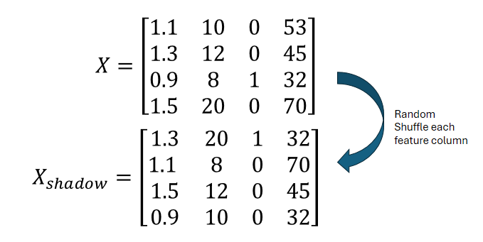

## 5. Step 2 – Concatenate Original and Shadow Features

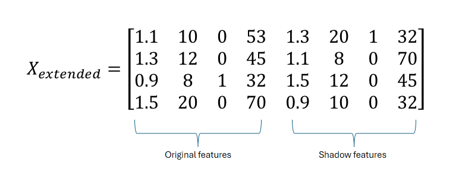

## 6. Step 3 – Random Forest Training with extended data

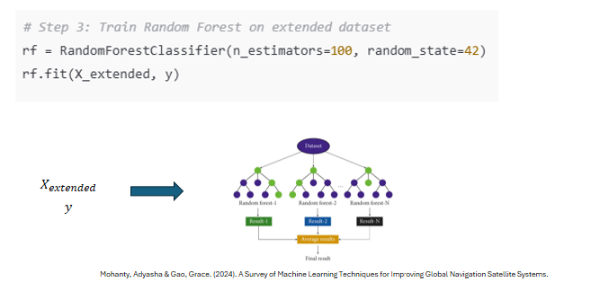

## 7. Step 4 – Features Importances

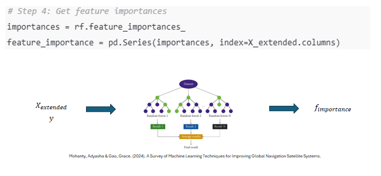

## 7. Step 5 – Features Importances Comparison

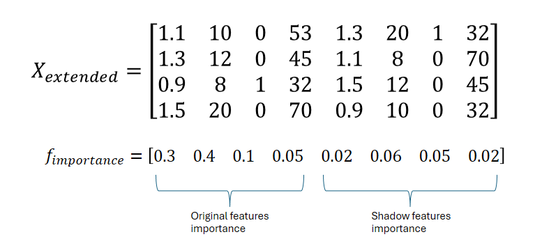

## 8. Step 5 – Features Importances Comparison

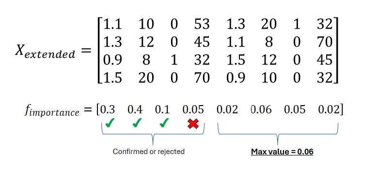

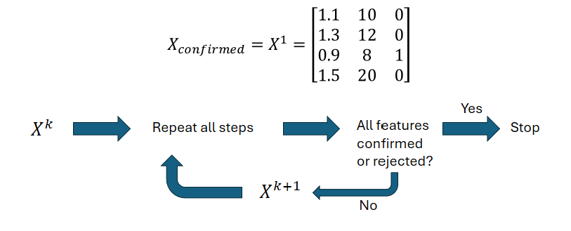

## 10. Tentative Features Treatment

Tentative features are those for which Boruta cannot confidently decide whether they are important or unimportant. Their importances are not consistently above or below the shadow features across iterations.

1. TentativeRoughFix (BorutaPy or Boruta R package)
- A post-processing step where tentative features are re-evaluated using median importance over all iterations.
- If their median importance is higher than the median of shadow features, mark as important; otherwise, unimportant.
- This is the default recommended way to resolve tentative features.
2. Modeling
- Final model (e.g., Random Forest, XGBoost, Neural Net) decides their usefulness.
3. Domain knowledge filtering
- Sometimes, tentative features may have strong theoretical or practical justification. In such cases, domain expertise can help retain or drop them.

## 10. Observations

- Each step coul be repeated multiple times (N iterations) to improve stability. A counting system tracks how often a feature is marked important or unimportant.
- Boruta was originally built around Random Forest, but it is not strictly limited to it. Any model that provides a reliable measure of feature importance can be used. Examples: Extra Trees, XGBoost, LightGBM, or other models with feature scoring.

## 11. Example

```python
!pip install Boruta
from sklearn.datasets import load_diabetes
from sklearn.ensemble import RandomForestRegressor
from boruta import BorutaPy
import pandas as pd
import numpy as np

# load the load_diabetes() dataset from sklearn
X, y = load_diabetes(return_X_y=True, as_frame=True)

# let's initialize a RF model
model = RandomForestRegressor(n_estimators=100, max_depth=5, random_state=42)

# let's initialize Boruta
feat_selector = BorutaPy(
    verbose=2,
    estimator=model,
    n_estimators='auto',
    max_iter=10  # number of iterations to perform
)

# train Boruta
# N.B.: X and y must be numpy arrays
feat_selector.fit(np.array(X), np.array(y))

# print support and ranking for each feature
print("\n------Support and Ranking for each feature------")
for i in range(len(feat_selector.support_)):
    if feat_selector.support_[i]:
        print("Passes the test: ", X.columns[i],
              " - Ranking: ", feat_selector.ranking_[i])
    else:
        print("Doesn't pass the test: ",
              X.columns[i], " - Ranking: ", feat_selector.ranking_[i])
```

```
Iteration: 	1 / 10
Confirmed: 	0
Tentative: 	10
Rejected: 	0
Iteration: 	2 / 10
Confirmed: 	0
Tentative: 	10
Rejected: 	0
Iteration: 	3 / 10
Confirmed: 	0
Tentative: 	10
Rejected: 	0
Iteration: 	4 / 10
Confirmed: 	0
Tentative: 	10
Rejected: 	0
Iteration: 	5 / 10
Confirmed: 	0
Tentative: 	10
Rejected: 	0
Iteration: 	6 / 10
Confirmed: 	0
Tentative: 	10
Rejected: 	0
Iteration: 	7 / 10
Confirmed: 	0
Tentative: 	10
Rejected: 	0
Iteration: 	8 / 10
Confirmed: 	4
Tentative: 	2
Rejected: 	4
Iteration: 	9 / 10
Confirmed: 	4
Tentative: 	2
Rejected: 	4


BorutaPy finished running.

Iteration: 	10 / 10
Confirmed: 	4
Tentative: 	0
Rejected: 	6

------Support and Ranking for each feature------
Doesn't pass the test:  age  - Ranking:  4
Doesn't pass the test:  sex  - Ranking:  7
Passes the test:  bmi  - Ranking:  1
Passes the test:  bp  - Ranking:  1
Doesn't pass the test:  s1  - Ranking:  5
Doesn't pass the test:  s2  - Ranking:  3
Doesn't pass the test:  s3  - Ranking:  2
Doesn't pass the test:  s4  - Ranking:  6
Passes the test:  s5  - Ranking:  1
Passes the test:  s6  - Ranking:  1
```

```python
X_filtered = feat_selector.transform(np.array(X))
print("\n------Selected Features------\n")
print(X_filtered)

# train the model
model.fit(X_filtered, y)

# compute predictions
predictions = model.predict(X_filtered)

# create a dataframe with real predictions and values
df = pd.DataFrame({'pred': predictions, 'observed': y})

# let's print the dataframe
print("\n------Prediction vs real values------\n")
print(df)

# compute RMSE
mse = ((df['pred'] - df['observed']) ** 2).mean()
rmse = np.sqrt(mse)
print("\n------RMSE------\n", round(rmse, 3))
```

```
------Selected Features------

[[ 0.06169621  0.02187239  0.01990749 -0.01764613]
 [-0.05147406 -0.02632753 -0.06833155 -0.09220405]
 [ 0.04445121 -0.00567042  0.00286131 -0.02593034]
 ...
 [-0.01590626  0.01729339 -0.04688253  0.01549073]
 [ 0.03906215  0.00121528  0.04452873 -0.02593034]
 [-0.0730303  -0.08141314 -0.00422151  0.00306441]]

------Prediction vs real values------

           pred  observed
0    192.978349     151.0
1     91.414977      75.0
2    167.482296     141.0
3    178.978614     206.0
4    114.609443     135.0
..          ...       ...
437  219.317929     178.0
438  103.966345     104.0
439   93.645648     132.0
440  184.893113     220.0
441  112.369922      57.0

[442 rows x 2 columns]

------RMSE------
 43.319
```

## 12. Pros and Cons of Boruta Algorithm

**✅ Pros**

- Identifies **all relevant features**, not just a minimal subset
- Works well with **tree-based models** (e.g., Random Forest, Gradient Boosted Trees)
- Helps detect **weak but useful** predictors that might be discarded by other methods
- Provides **clear decision outcomes** (Accepted / Rejected / Tentative)
- Can improve **model interpretability** and reduce overfitting

**⚠️ Cons**

- **Computationally expensive** (many iterations with Random Forests)
- Results depend on **Random Forest feature importance** quality
- Can retain **too many features**, requiring additional pruning
- Not always optimal for **high-dimensional datasets** with thousands of variables
- May be **sensitive to hyperparameters** (e.g., number of trees, iterations, thresholds)

## 13. Practical Tips

- Use **enough trees** in the Random Forest (hundreds) for stable importances.
- Increase **iterations** for more reliable accept/reject decisions.
- Boruta is **conservative**: it aims to keep *all relevant* features; you can later apply additional pruning if you need a minimal subset.
- For real projects, consider using a well-tested implementation such as **BorutaPy** or libraries that support Boruta variants.

## 14. References and Further Reading

- Kursa, M.B. & Rudnicki, W.R. (2010). Feature Selection with the Boruta Package. *Journal of Statistical Software*, 36(11). DOI:10.18637/jss.v036.i11
- Breiman, L. (2001). Random Forests. *Machine Learning*, 45, 5–32.
- Mohanty, A., & Gao, G. (2024). A Survey of ML Techniques for Improving GNSS.
- BorutaPy (Python implementation): https://github.com/scikit-learn-contrib/boruta_py